# SIVOCS Hypothesis Testing

2022-07-22

# Example 1: A1 | Problem: Explaining a 3. unknown variable with the relation between 2 variables

Hypothesis: Transdisciplinarity is usually an important cornerstone for social innovation, although it is no condition for it. Moreover, not all transdisciplinary research automatically contributes to social innovation. Nevertheless, we assume that a higher experience in transdisciplinary research might point to a higher propensity for social innovation.

A1, E1 correlation Matrix:

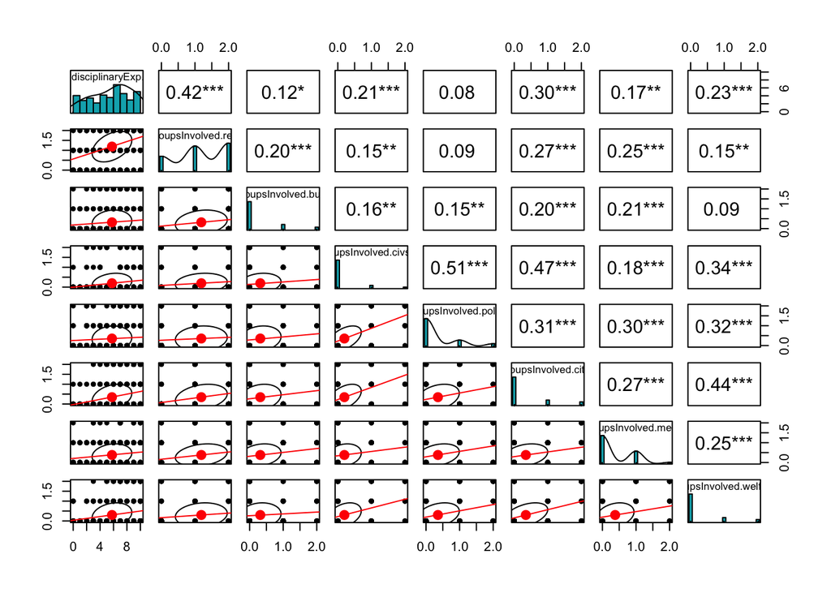

A1, D1.2, D1.3, D2 correlation Matrix

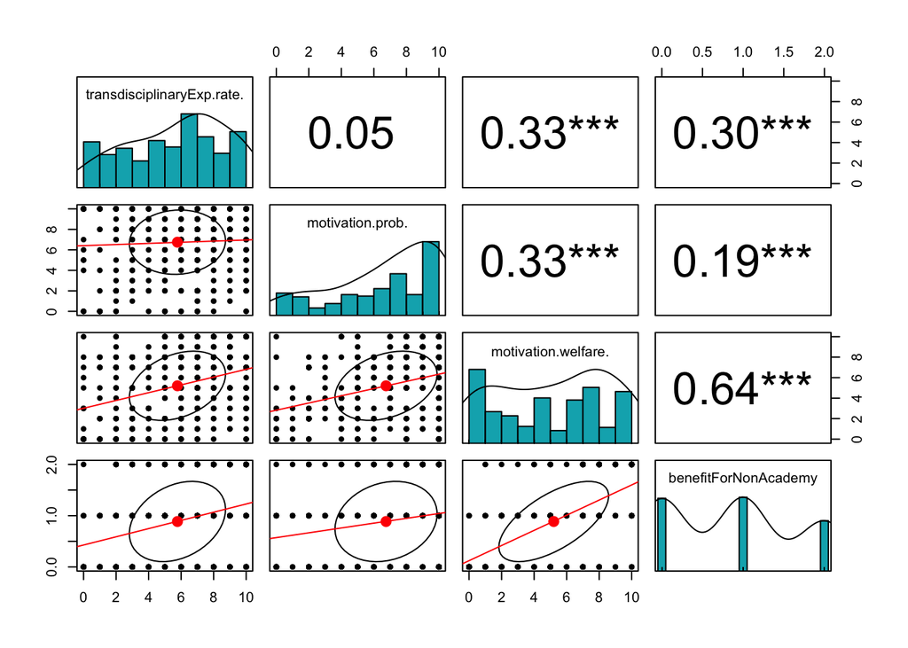

## A1: Factor analysis

There are 2 possible approaches for factor analysis. Either with including all possible variables or analysing each correlation in its own factor analysis but I am including all of those here.

Find the optimal number of factors:

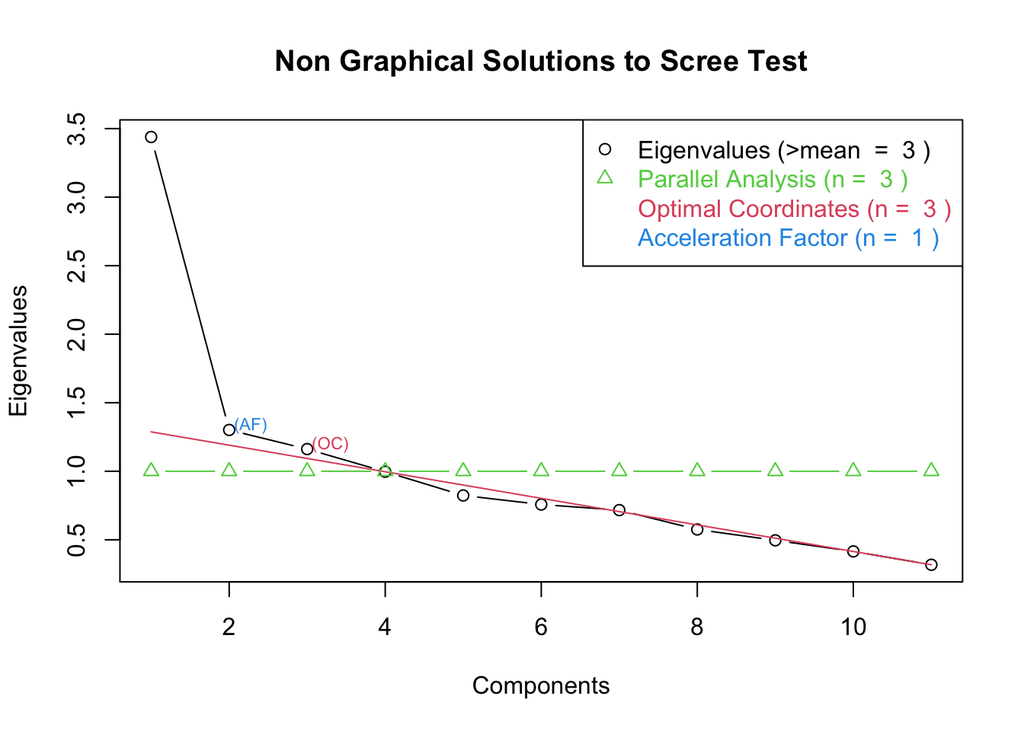

```
##
## Call:
## factanal(x = na.omit(a1.df), factors = 3, rotation = "varimax")
##
## Uniquenesses:
## transdisciplinaryExp.rate.        groupsInvolved.res.
##                      0.626                      0.528
##       groupsInvolved.busi.     groupsInvolved.civsoc.
##                      0.899                      0.500
##     groupsInvolved.policy.      groupsInvolved.citiz.
##                      0.623                      0.539
##      groupsInvolved.media.    groupsInvolved.welfare.
##                      0.804                      0.698
##           motivation.prob.        motivation.welfare.
##                      0.861                      0.086
##       benefitForNonAcademy
##                      0.505
##
## Loadings:
##                            Factor1 Factor2 Factor3
## transdisciplinaryExp.rate. 0.148   0.215   0.554
## groupsInvolved.res.        0.114           0.677
## groupsInvolved.busi.       0.168   0.161   0.217
## groupsInvolved.civsoc.     0.685   0.117   0.131
## groupsInvolved.policy.     0.594   0.149
## groupsInvolved.citiz.      0.587           0.334
## groupsInvolved.media.      0.315           0.309
## groupsInvolved.welfare.    0.463   0.227   0.189
## motivation.prob.                   0.371
## motivation.welfare.        0.193   0.920   0.174
## benefitForNonAcademy       0.296   0.572   0.285
##
##                Factor1 Factor2 Factor3
## SS loadings      1.670   1.476   1.186
## Proportion Var   0.152   0.134   0.108
## Cumulative Var   0.152   0.286   0.394
##
## Test of the hypothesis that 3 factors are sufficient.
## The chi square statistic is 65.42 on 25 degrees of freedom.
## The p-value is 1.8e-05
```

## A1: Var. combination

According to the correlation matrix and factor analysis, following in E1 can be combined:

- Representatives of civil soc. orgs
- Policymakers
- Citizens
- Welfare, education workers

```r
a1.df$civsoc.policy.citiz.welfare <- (a1.df$groupsInvolved.civsoc. + a1.df$groupsInvolved.policy. + a1.df$groupsInvolved.welfare. + a1.df$groupsInvolved.citiz. )/4
```

Another approach could be taking the whole variable as stakeholder engagement (other than researchers)

```r
a1.df$e1_diff_res <- (a1.df$groupsInvolved.civsoc. + a1.df$groupsInvolved.policy. + a1.df$groupsInvolved.welfare. + a1.df$groupsInvolved.citiz. + a1.df$groupsInvolved.busi. + a1.df$groupsInvolved.media.)/6
```

Also from the D questions, following variables show strong correlation

- Motivation for welfare
- Non academic benefit pursuit

```r
a1.df$welfare.nonAcademy <- (a1.df$groupsInvolved.welfare. + a1.df$benefitForNonAcademy)/2
```

Correlation after combination:

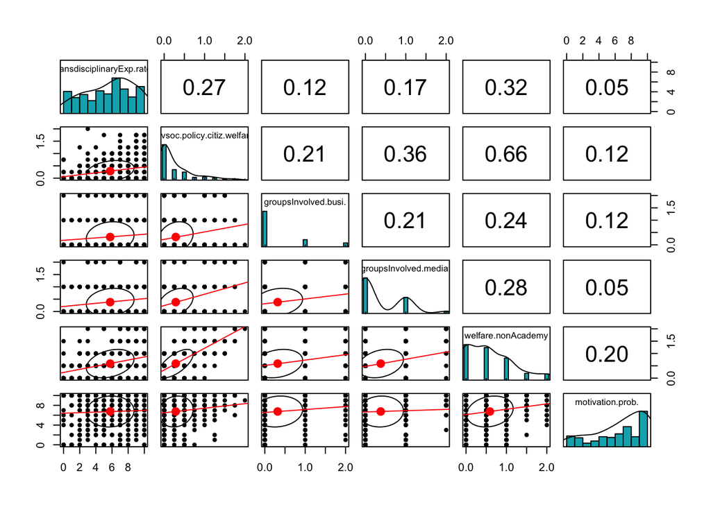

```r
pairs.panels(a1.df[, c("transdisciplinaryExp.rate.",
                       "civsoc.policy.citiz.welfare",
                       "groupsInvolved.busi.",
                       "groupsInvolved.media.",
                       "welfare.nonAcademy",
                       "motivation.prob."
                       )],
             method = "pearson", # correlation method
             hist.col = "#00AFBB",
             density = TRUE,  # show density plots
             ellipses = TRUE, # show correlation ellipses
             lm = TRUE
             )
```

## A1: Linear Model

Explaining stakeholder involvement with the transdisciplinary experience does not make much sense. Transdisciplinary research should involve stakeholder engagement anyways. We can only compare the effect of the motivation variables with the effect of transdisciplinarity

|  | civsoc.policy.citiz.welfare |  |  |
| --- | --- | --- | --- |
| Predictors | Estimates | CI | p |
| (Intercept) | -0.07 | -0.20 – 0.05 | 0.255 |
| motivation prob | -0.00 | -0.01 – 0.01 | 0.912 |
| motivation welfare | 0.04 | 0.03 – 0.05 | **<0.001** |
| transdisciplinaryExp rate | 0.03 | 0.01 – 0.04 | **0.001** |
| Observations | 330 |  |  |
| R<sup>2</sup> / R<sup>2</sup> adjusted | 0.175 / 0.167 |  |  |

A linear model with the whole e1 combination:

|  | e1_diff_res |  |  |
| --- | --- | --- | --- |
| Predictors | Estimates | CI | p |
| (Intercept) | -0.02 | -0.13 – 0.08 | 0.698 |
| motivation prob | 0.00 | -0.01 – 0.01 | 0.973 |
| motivation welfare | 0.03 | 0.02 – 0.05 | **<0.001** |
| transdisciplinaryExp rate | 0.02 | 0.01 – 0.04 | **<0.001** |
| Observations | 327 |  |  |
| R<sup>2</sup> / R<sup>2</sup> adjusted | 0.186 / 0.179 |  |  |

# Example 2: C1 | Problem: Too many independent variables with multicollinearity -> Unstable models

**Hypothesis**: The self-assessment is an important variable to identify the contribution to social innovation. The higher the self-assessment is the higher is probably the real contribution to social innovation. We assume, however, a trend towards under estimation. Therefore, it is important to confront the self-assessment with other indicators.

- Relation with E1 (stakeholder engagement)
- Relation with D1.2 and D1.3

## Inner corelations in E1

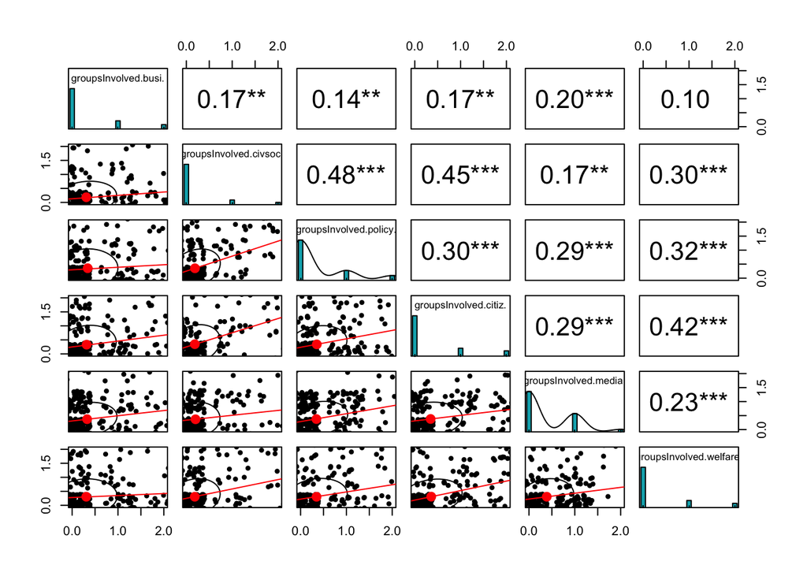

```r
corr_matrix_plt(e1.df[, -1])
```

- Combine `civsoc` `policy` `citit` `welfare`

```r
head(e1.modf_civil)
```

```
##   bus med civ
## 1   1   0 0.0
## 2   0   0 0.0
## 3   2   1 0.0
## 4   0   1 0.5
## 5   0   0 0.0
## 6   0   1 0.5
```

## Inner correlations in D1.2 and D1.3

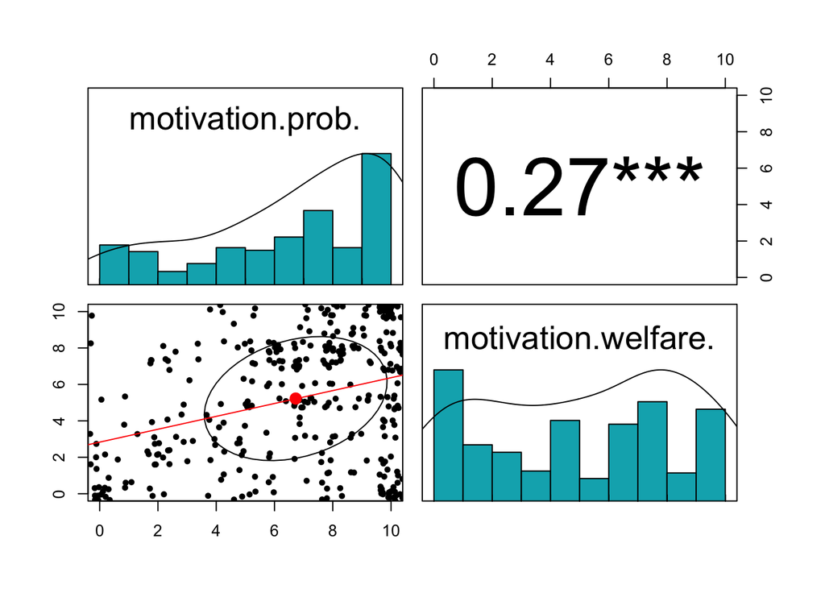

```r
corr_matrix_plt(d1.df[, c(2,3)])
```

## Correlation Matrix of C1 with modified E1 and D1.2/3

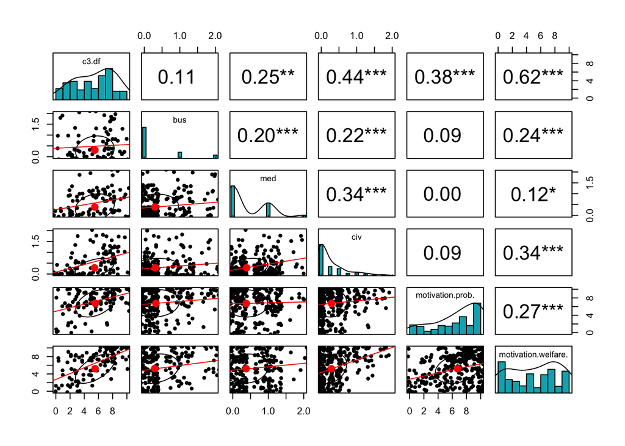

```r
corr_matrix_plt(cbind(c3.df, e1.modf_civil, d1.df[, c(2,3)]))
```

## LR Model

#### Alternative 1

c3

Predictors

Estimates

CI

p

(Intercept)

0.76

-0.66 – 2.19

0.290

bus

-0.40

-1.00 – 0.20

0.185

med

0.38

-0.35 – 1.10

0.307

civ

0.10

-2.64 – 2.85

0.940

motivation prob

0.23 **

0.07 – 0.39

**0.006**

motivation welfare

0.40 ***

0.20 – 0.59

**<0.001**

civ * motivation welfare

0.07

-0.27 – 0.41

0.676

Observations

100

R<sup>2</sup> / R<sup>2</sup> adjusted

0.475 / 0.441

- p<0.05 ** p<0.01 *** p<0.001

#### Alternative 2

c3

Predictors

Estimates

CI

p

(Intercept)

0.82

-0.56 – 2.20

0.241

civ

0.00

-2.69 – 2.69

0.997

motivation prob

0.22 **

0.06 – 0.39

**0.007**

motivation welfare

0.41 ***

0.22 – 0.60

**<0.001**

civ * motivation welfare

0.08

-0.25 – 0.40

0.635

Observations

103

R<sup>2</sup> / R<sup>2</sup> adjusted

0.455 / 0.433

- p<0.05 ** p<0.01 *** p<0.001

Mehrere Variablen sind fast unmöglich, Vorschlag?

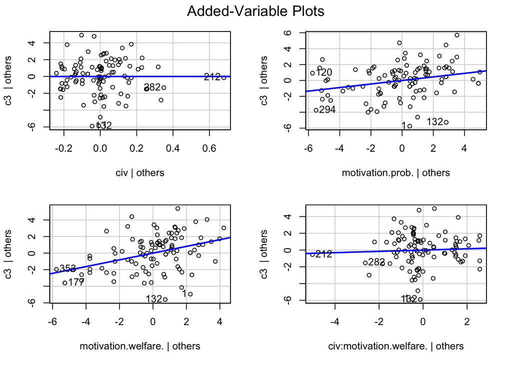

# Example 3: D1 | Problem: What are we modeling & ?Water is wet?

Hypothesis: The motivation to directly address a natural, technical economic or social problem or even to improve the human condition/welfare can be a strong component for social innovation, although it is not a pre-condition. The motivation to better understand a natural, technical, economic or social phenomenon, however, points to a rather “regular” scientific motivation, without directly aiming to problem solving or improving human/welfare conditions.

RE-formulation: Motivation for address a natural, technical economic or social problem or even to improve the human condition/welfare are more likely to produce to new or better services, products, processes, or ways of doing things compared to motivation to better understand a natural, technical, economic or social phenomenon.

We have 3 different variables in D1:

```
## [1] "motivation.pheno."   "motivation.prob."    "motivation.welfare."
```

How do the independent variable correlate against each other

Should we handle the collinearity between the dependent variables? We want to combine the last 2 but the first 2 correlate better

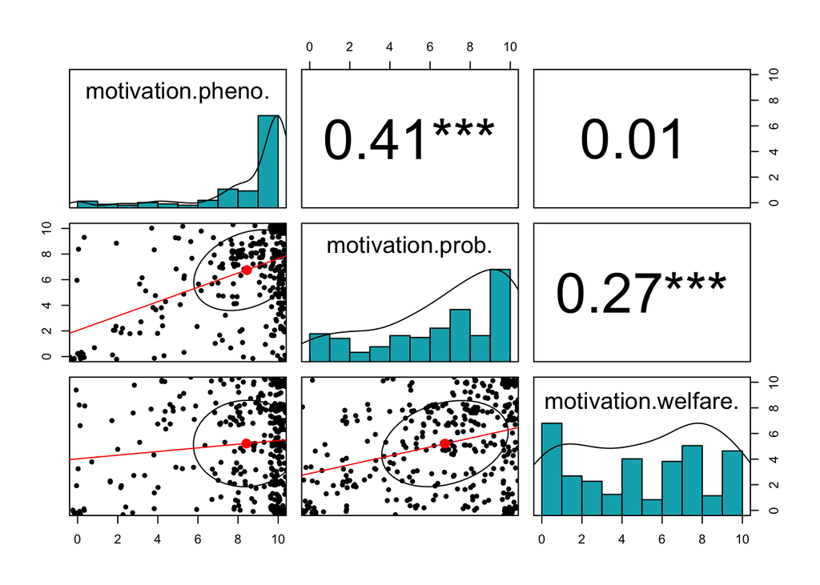

Dependent variable G1: To what degree has your project directly contributed to new or better services, products, processes, or ways of doing things that were targeted towards …

```r
head(g1.df)
```

```
##   impactTargetGroup.pub. impactTargetGroup.busi. impactTargetGroup.socgr.
## 1                      0                       0                        0
## 2                      0                       0                        0
## 3                      1                       5                        0
## 4                      0                       0                        0
## 5                      5                       0                        0
## 6                      2                       0                        3
##   impactTargetGroup.welfare. impactTargetGroup.civsoc.
## 1                          0                         0
## 2                          0                         0
## 3                          0                         0
## 4                          0                         0
## 5                          0                         0
## 6                          4                         0
##   impactTargetGroup.policy. impactTargetGroup.acad.
## 1                         0                      10
## 2                         0                       7
## 3                         0                       8
## 4                         0                      10
## 5                         0                      10
## 6                         2                       7
```

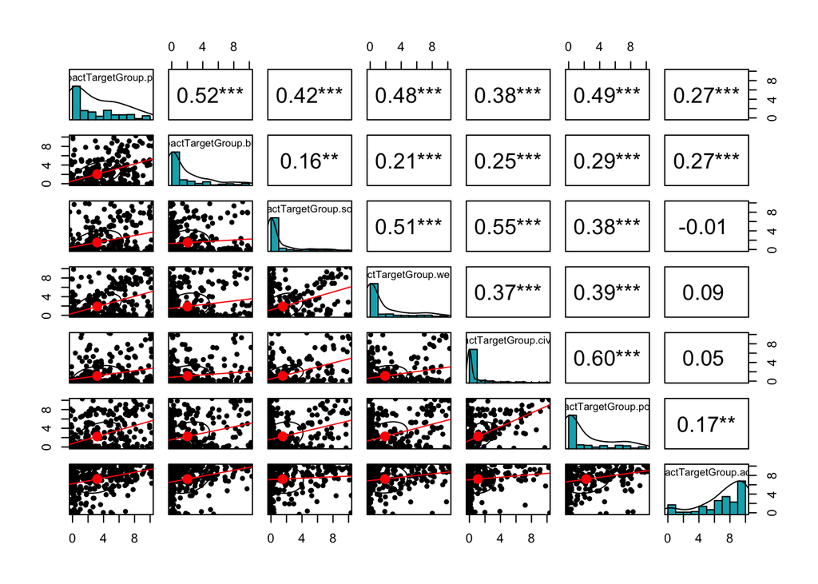

Combining g1’s all sub-variables other than acad. into 1 single variable for **testing purposes**

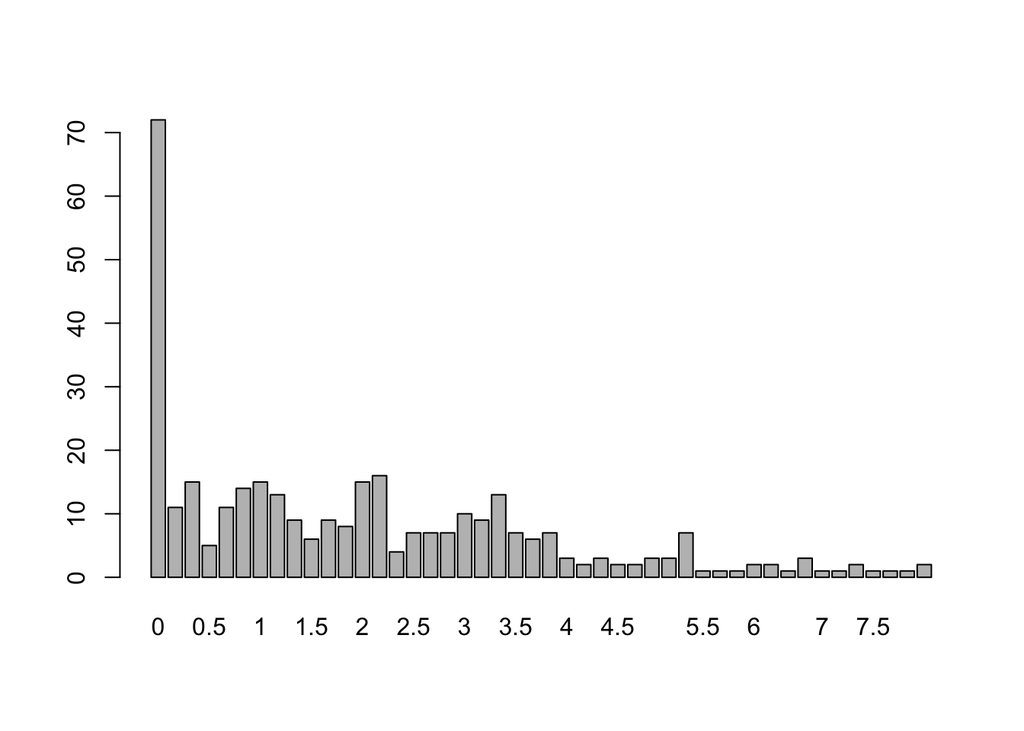

```r
library(plotly)
barplot(table(g1.modf_civil))
```

Correlation between D1 variables and G1

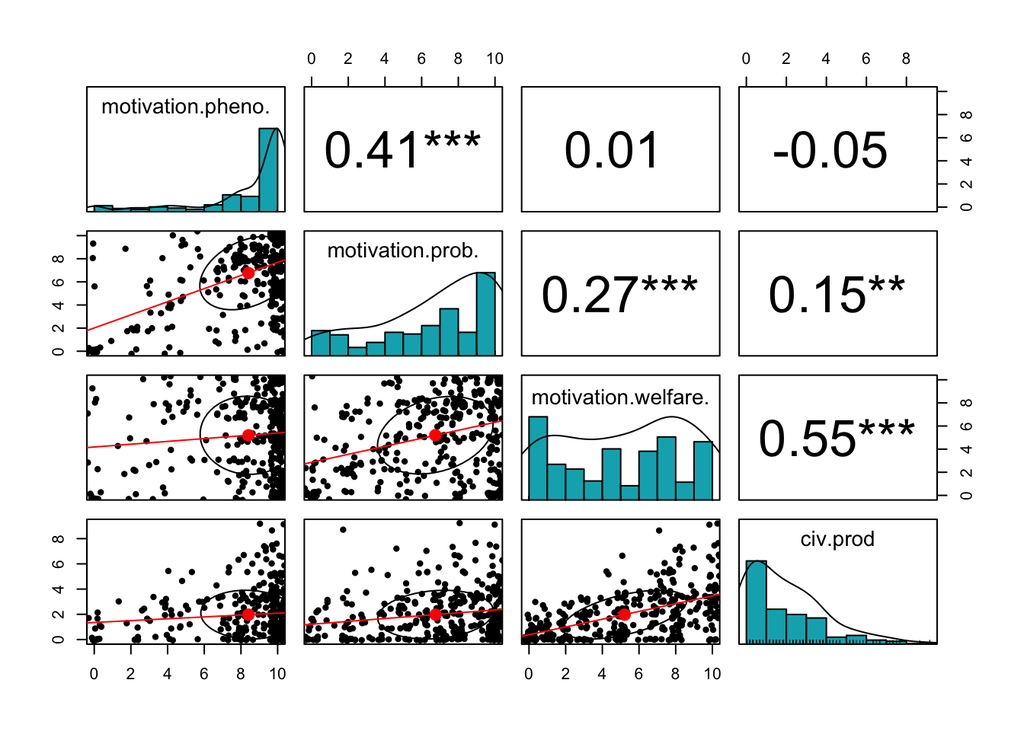

```r
d1.test.df <- as.data.frame(cbind(d1.df,
                                  "civ.prod" = g1.modf_civil))

corr_matrix_plt(d1.test.df)
```

LM model

```r
d1.test.lm <- lm(data = d1.test.df, civ.prod ~ motivation.pheno. + motivation.prob. + motivation.welfare. )

tab_model(d1.test.lm)
```

|  | civ.prod |  |  |
| --- | --- | --- | --- |
| Predictors | Estimates | CI | p |
| (Intercept) | 0.15 | -0.47 – 0.78 | 0.629 |
| motivation pheno | 0.04 | -0.04 – 0.11 | 0.368 |
| motivation prob | -0.01 | -0.08 – 0.06 | 0.820 |
| motivation welfare | 0.31 | 0.25 – 0.36 | **<0.001** |
| Observations | 336 |  |  |
| R<sup>2</sup> / R<sup>2</sup> adjusted | 0.292 / 0.286 |  |  |

What do we found out: Social motivation produces products for society?

# Example 4: E1 | Relatively straight forward

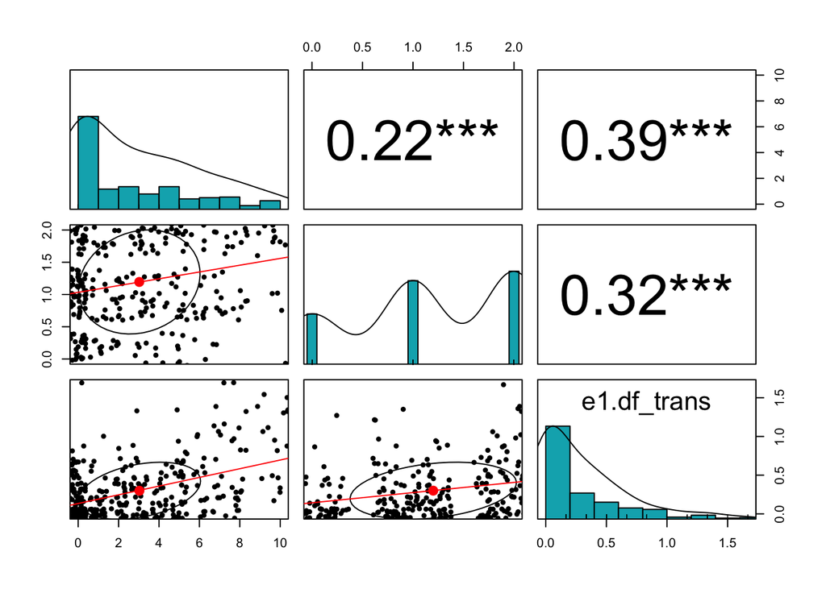

```r
corr_matrix_plt(cbind(data$familiarWithSI.response., e1.df$groupsInvolved.res., e1.df_trans))
```

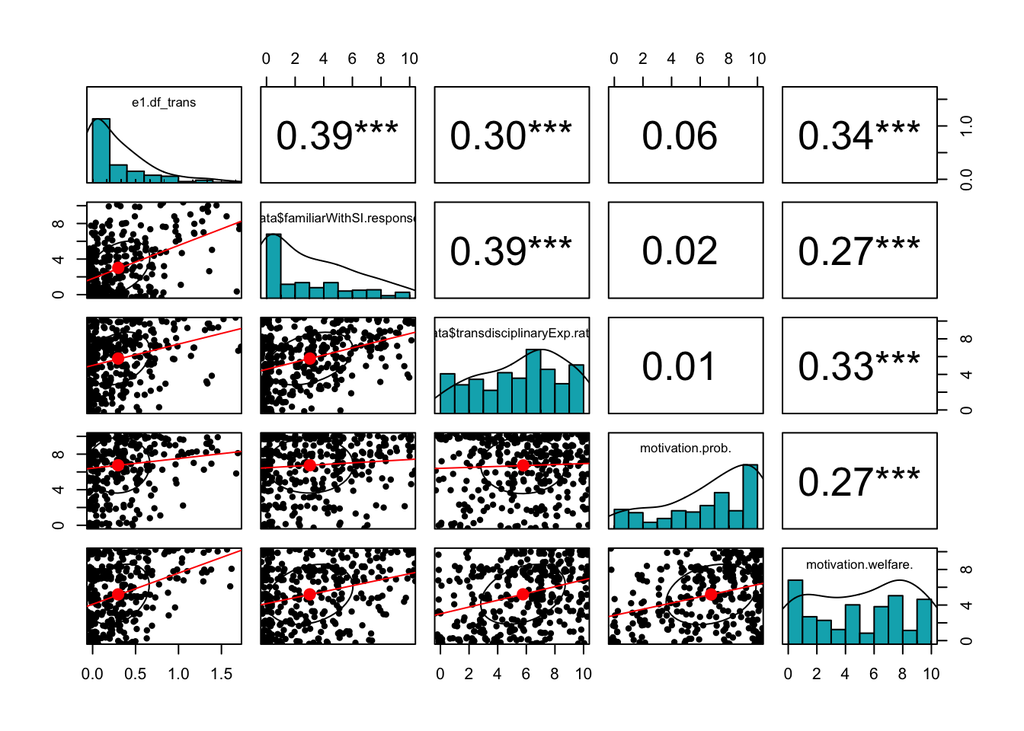

```r
corr_matrix_plt(cbind(e1.df_trans, data$familiarWithSI.response., data$transdisciplinaryExp.rate., d1.df[, 2:3]))
```

```r
e1.df_model <- data.frame(cbind(e1.df_trans, data$familiarWithSI.response., data$transdisciplinaryExp.rate., d1.df[, 2:3]))
e1.model <- lm(data=e1.df_model, e1.df_trans ~ data$familiarWithSI.response. + data$transdisciplinaryExp.rate. + d1.df[, 2] + d1.df[, 3])
```

```r
summary(e1.model)
```

```
##
## Call:
## lm(formula = e1.df_trans ~ data$familiarWithSI.response. + data$transdisciplinaryExp.rate. +
##     d1.df[, 2] + d1.df[, 3], data = e1.df_model)
##
## Residuals:
##      Min       1Q   Median       3Q      Max
## -0.59525 -0.20926 -0.04866  0.14573  1.44388
##
## Coefficients:
##                                   Estimate Std. Error t value Pr(>|t|)
## (Intercept)                     -2.184e-02  4.996e-02  -0.437    0.662
## data$familiarWithSI.response.    4.455e-02  6.367e-03   6.998 1.52e-11 ***
## data$transdisciplinaryExp.rate.  7.774e-03  6.489e-03   1.198    0.232
## d1.df[, 2]                      -9.305e-05  5.647e-03  -0.016    0.987
## d1.df[, 3]                       2.794e-02  5.683e-03   4.916 1.41e-06 ***
## ---
## Signif. codes:  0 '***' 0.001 '**' 0.01 '*' 0.05 '.' 0.1 ' ' 1
##
## Residual standard error: 0.3045 on 322 degrees of freedom
##   (34 observations deleted due to missingness)
## Multiple R-squared:  0.2936, Adjusted R-squared:  0.2848
## F-statistic: 33.46 on 4 and 322 DF,  p-value: < 2.2e-16
```